# R Notebook

# sf paketi ile mekansal veri analizi

R’da mekansal veriler ile çalışmak için *sf* paketi kullanacağız. Göreceli olarak dahayeni bir paket olan *sf*, *sp* paketinin yerini aldı.  
Uluslararası bir konsorsiyum olan Open Geospatial (OGC) standartlarını desteklediği için yeni projelerin `sf` paketi kullanılarak yapılması tavsiye ediliyor.

**Hatırlatma : klasik R veri tipleri**

R’ın sunduğu temel veri tipleri aşağıda verilmiştir.

Veri tiplerinin yanında gösterilen kodları çalıştırarak sonuçları analiz edelim.

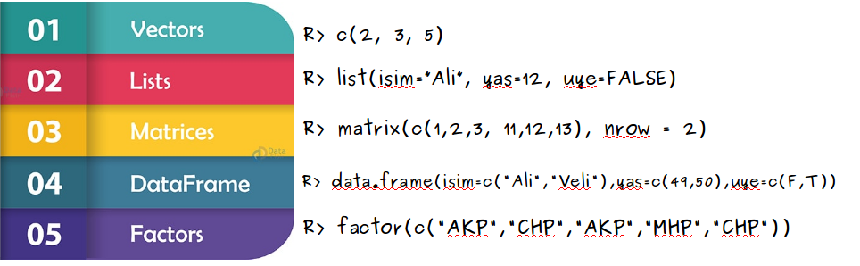

**Hatırlatma :**

`data.frame` nesnesi verileri tablo formatında tutar:

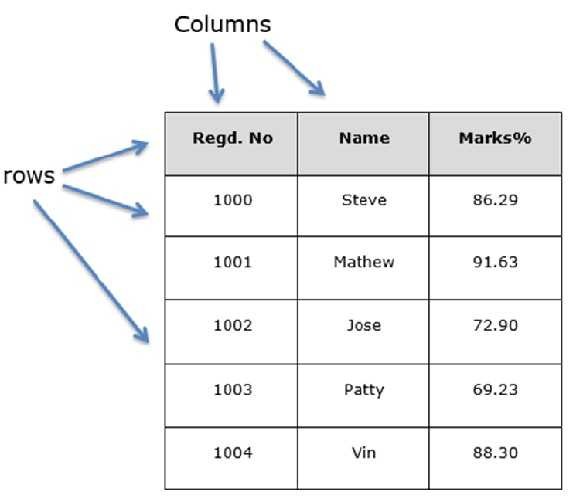

# sf nesnesi

`sf` nesnesi klasik `data.frame` nesnesinden kalıtım alır.

Bir `sf` nesnesinin `sfc` sınıfından bir sütunu olması gerekir. Bu sütun, geometri verilerini tutar. `sfc` nesnesi herbir `data.frame` satırı için bir `sfg` nesnesi tutan bir `list` nesnesidir.

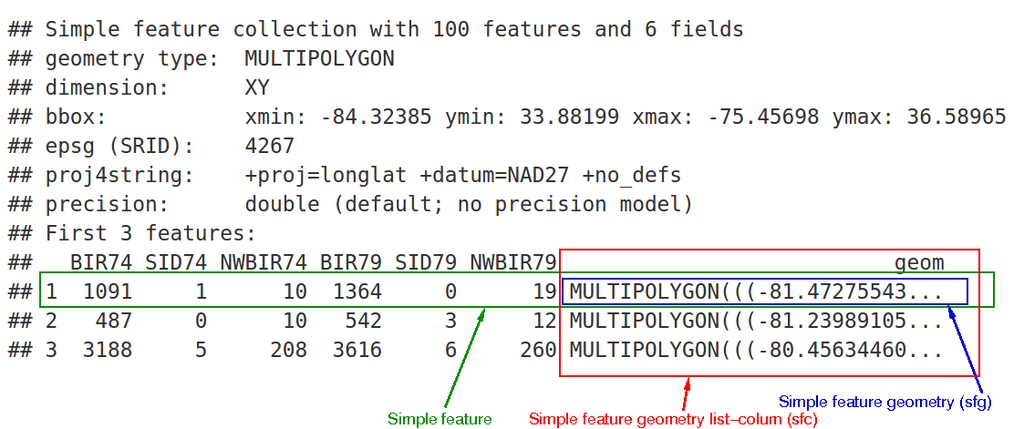

## data.frame nesnesi ile sf yaratmak

*meuse* adlı data.frame, *x* ve *y* sütunlarında mekansal koordinatlar, diğer satırlarında ise çeşitli çevresel veriler içerir.

```r
library(sf)
data('meuse', package = "sp")
class(meuse)
```

```
## [1] "data.frame"
```

```r
head(meuse)
```

|  | x | y | cadmium | copper | lead | zinc | elev | dist | om | ffreq | soil | lime | landuse | dist.m |
| --- | --- | --- | --- | --- | --- | --- | --- | --- | --- | --- | --- | --- | --- | --- |
| 1 | 181072 | 333611 | 11.7 | 85 | 299 | 1022 | 7.909 | 0.00135803 | 13.6 | 1 | 1 | 1 | Ah | 50 |
| 2 | 181025 | 333558 | 8.6 | 81 | 277 | 1141 | 6.983 | 0.01222430 | 14.0 | 1 | 1 | 1 | Ah | 30 |
| 3 | 181165 | 333537 | 6.5 | 68 | 199 | 640 | 7.800 | 0.10302900 | 13.0 | 1 | 1 | 1 | Ah | 150 |
| 4 | 181298 | 333484 | 2.6 | 81 | 116 | 257 | 7.655 | 0.19009400 | 8.0 | 1 | 2 | 0 | Ga | 270 |
| 5 | 181307 | 333330 | 2.8 | 48 | 117 | 269 | 7.480 | 0.27709000 | 8.7 | 1 | 2 | 0 | Ah | 380 |
| 6 | 181390 | 333260 | 3.0 | 61 | 137 | 281 | 7.791 | 0.36406700 | 7.8 | 1 | 2 | 0 | Ga | 470 |

*meuse* data.frame nesnesini *sf*’e çevirmek için *st_as_sf()* fonksiyonunu kullanacağız.

```r
ms <- st_as_sf(
  meuse,
  coords = c('x', 'y'),
  crs = "+init=epsg:28992"
)
class(ms)
```

```
## [1] "sf"         "data.frame"
```

```r
head(ms)
```

|  | cadmium | copper | lead | zinc | elev | dist | om | ffreq | soil | lime | landuse | dist.m | geometry |
| --- | --- | --- | --- | --- | --- | --- | --- | --- | --- | --- | --- | --- | --- |
| 1 | 11.7 | 85 | 299 | 1022 | 7.909 | 0.00135803 | 13.6 | 1 | 1 | 1 | Ah | 50 |  |
| 2 | 8.6 | 81 | 277 | 1141 | 6.983 | 0.01222430 | 14.0 | 1 | 1 | 1 | Ah | 30 |  |
| 3 | 6.5 | 68 | 199 | 640 | 7.800 | 0.10302900 | 13.0 | 1 | 1 | 1 | Ah | 150 |  |
| 4 | 2.6 | 81 | 116 | 257 | 7.655 | 0.19009400 | 8.0 | 1 | 2 | 0 | Ga | 270 |  |
| 5 | 2.8 | 48 | 117 | 269 | 7.480 | 0.27709000 | 8.7 | 1 | 2 | 0 | Ah | 380 |  |
| 6 | 3.0 | 61 | 137 | 281 | 7.791 | 0.36406700 | 7.8 | 1 | 2 | 0 | Ga | 470 |  |

Yukarıdaki koda baktığımızda gözümüze çarpan şeyler: - `ms` adlı değişken’in sınıfı : “sf” ve bu “data.frame” sınıfından kalıt alıyor - nedir bu EPSG 28992?

EPSG kodları hakkında daha fazla bilgiyi [spatialreference.org](http://spatialreference.org/ref/epsg/amersfoort-rd-new/)’da bulabiliriz.

## Basit sf Geometri Türleri

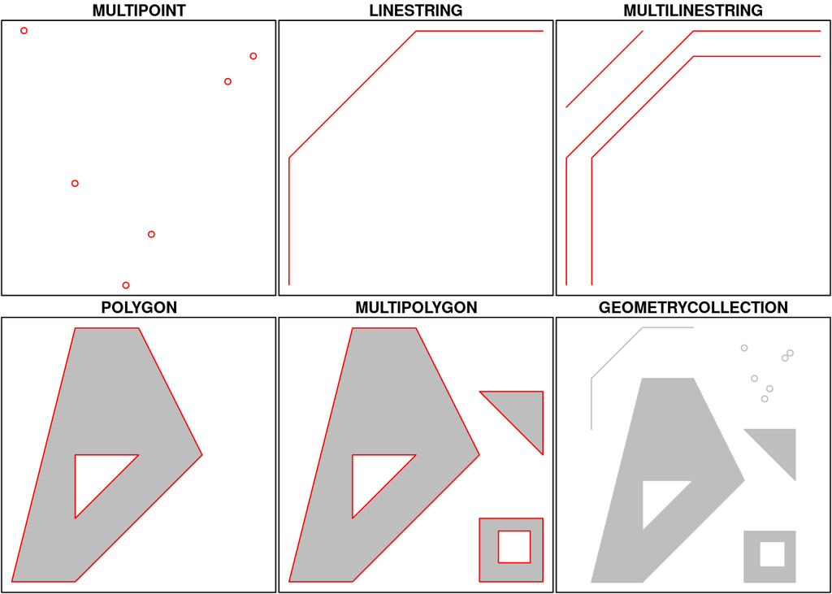

## Harita projeksiyon sistemleri

3 boyutlu bir nesne olan gezegenimizin yüzeyini 2 boyutlu kağıt ve ekranlarda göstermek için harita projeksiyon sistemleri kullanmaktayız.

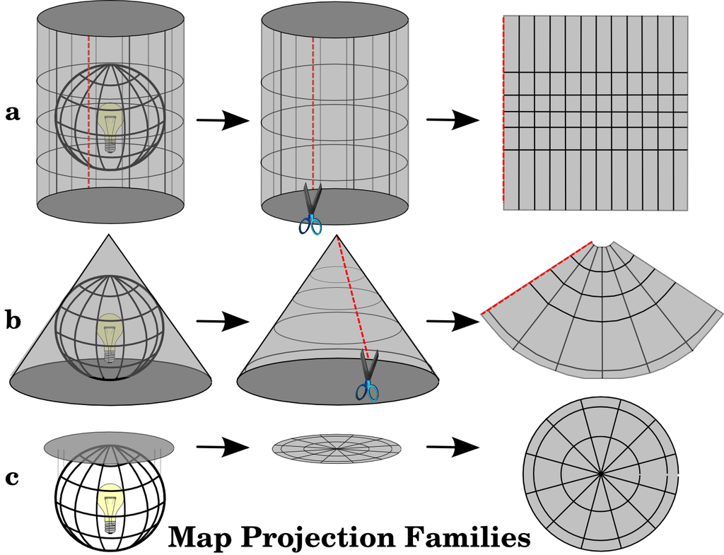

Doğru projeksiyon sistemi seçimi için mekanın ve yapılacak analiz türünün çok iyi bilnmesi gerekir.

## R değişkenleri ile sf nesnesi yaratımı

```r
library(sf)
#data.frame nesnesi oluştur
d = data.frame(a = 1:2)
#her bir data.frame satırı için sfg nesnesi oluştur
pt1 = st_point(c(0,1))
pt2 = st_point(c(1,1))
class(pt1)
```

```
## [1] "XY"    "POINT" "sfg"
```

```r
#sfc nesnesi oluştur ve bunu "geom" adlı sütuna taşı
d$geom = st_sfc(pt1, pt2)
#sf nesnesi yarat
my_sf = st_as_sf(d)
class(my_sf)
```

```
## [1] "sf"         "data.frame"
```

## sf nesnelerinin görsellenmesi

*sf* paketi ile gelen *plot* metodu ile enteraktif olmayan ama hafızaya yük bindirmeyen haritalar çizebiliriz. Aşağıdaki kod ile sadece *geometry* sütunu ile harita altlığı çiziyoruz. **Attribute data** bilgisi görsellemiyoruz.

```r
library(sf)
demo(nc, ask = FALSE, echo = FALSE)
```

```
## Attribute-geometry relationship: 0 constant, 8 aggregate, 6 identity
## geometry type:  MULTIPOLYGON
## dimension:      XY
## bbox:           xmin: -84.32385 ymin: 33.88199 xmax: -75.45698 ymax: 36.58965
## epsg (SRID):    4267
## proj4string:    +proj=longlat +datum=NAD27 +no_defs
```

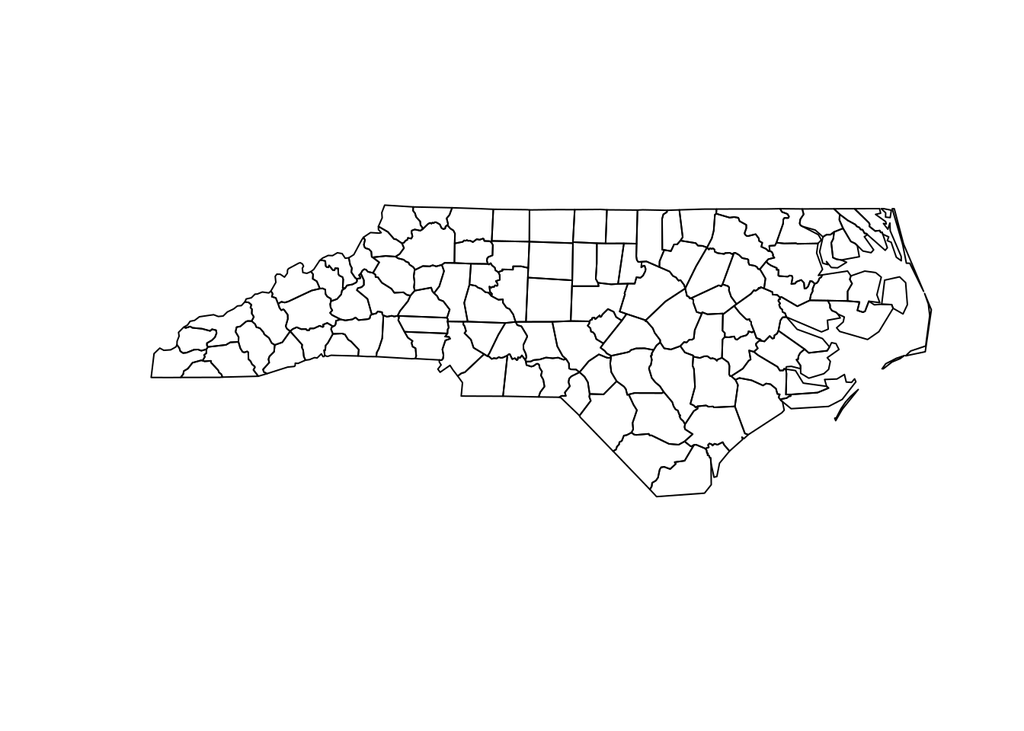

```r
plot(st_geometry(nc))
```

## leaflet paketi ile harita yapımı:

*leaflet* paketi ile `d3` (Javascript) tabanlı enteraktif harita yapımı çok kolay. Bu haritaları yaparken hafızada ne kadar yer tuttuklarına bakmak yararlı olur. Çok fazla veri çizildiği taktirde tarayıcıyı ve hatta makinayi kilitleyebilir. Daha fazla bilgi icin [leaflet web sitesi](https://rstudio.github.io/leafletweb).

```r
library(leaflet)
m = leaflet() %>%
   addTiles() %>%
   setView(36, 39, zoom=6) %>%
   addMarkers(27.43054, 37.034407, popup = "Bodrum'da artık bir IT dünyası var!", label = "Bodrum")
m  # a map with the default OSM tile layerers(lng=174.768, lat=-36.752, popup="The birthplace of R")
```

[interactive chart not shown]

# Enteraktif harita kontrolleri

Haritada görsellenen katmanları *leaflet* paketi ile gelen kontrolleri kullanarak kapatıp açmak mümkün.

```r
outline <- quakes[chull(quakes$long, quakes$lat),]

map <- leaflet(quakes) %>%
  # Base groups
  addTiles(group = "OSM (default)") %>%
  addProviderTiles(providers$Stamen.Toner, group = "Toner") %>%
  addProviderTiles(providers$Stamen.TonerLite, group = "Toner Lite") %>%
  # Overlay groups
  addCircles(~long, ~lat, ~10^mag/5, stroke = F, group = "Quakes") %>%
  addPolygons(data = outline, lng = ~long, lat = ~lat,
    fill = F, weight = 2, color = "#FFFFCC", group = "Outline") %>%
  # Layers control
  addLayersControl(
    baseGroups = c("OSM (default)", "Toner", "Toner Lite"),
    overlayGroups = c("Quakes", "Outline"),
    options = layersControlOptions(collapsed = FALSE)
  )
map
```

[interactive chart not shown]

Bir *sf* nesnesi ile doğrudan enteraktif harita çizmek için *mapview* paketini kullanabiliriz :

```r
library(mapview)
library(sf)
demo(nc, ask = FALSE, echo = FALSE)
```

```
## Attribute-geometry relationship: 0 constant, 8 aggregate, 6 identity
## geometry type:  MULTIPOLYGON
## dimension:      XY
## bbox:           xmin: -84.32385 ymin: 33.88199 xmax: -75.45698 ymax: 36.58965
## epsg (SRID):    4267
## proj4string:    +proj=longlat +datum=NAD27 +no_defs
```

```r
mapview(nc["BIR74"], col.regions = sf.colors(10),map.types = mapviewGetOption("basemaps")[3])
```

[interactive chart not shown]

*tmap* paketini kullanarak *sf* nesnesi ile doğrudan harita çizebiliriz

```r
library(sf)
library(tmap)
demo(nc, ask = FALSE, echo = FALSE)
```

```
## Attribute-geometry relationship: 0 constant, 8 aggregate, 6 identity
## geometry type:  MULTIPOLYGON
## dimension:      XY
## bbox:           xmin: -84.32385 ymin: 33.88199 xmax: -75.45698 ymax: 36.58965
## epsg (SRID):    4267
## proj4string:    +proj=longlat +datum=NAD27 +no_defs
```

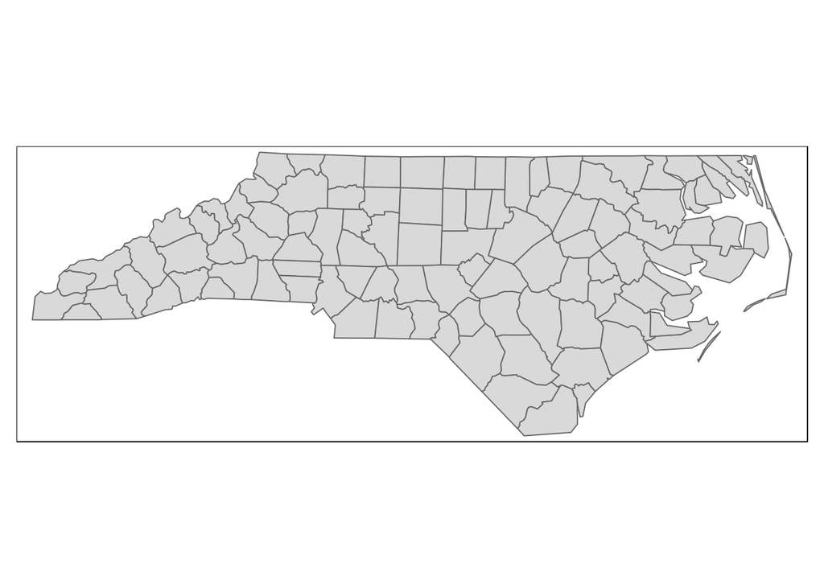

```r
qtm(nc)
```

```r
tmap_mode("view")
```

```
## tmap mode set to interactive viewing
```

```r
## tmap mode set to interactive viewing
# if (Sys.getenv("USER") != "CRAN")
tm_shape(nc) + tm_fill("BIR74", palette = sf.colors(5))
```

[interactive chart not shown]

## World map data

*spData* paketi çeşitli mekansal veritabanları içermekte. Mesela dünya haritasını değişik boyutları ile çizelim.

```r
library(sf)
world <- st_read(system.file("shapes/world.gpkg", package="spData"))
names(world)
```

```
##  [1] "iso_a2"    "name_long" "continent" "region_un" "subregion"
##  [6] "type"      "area_km2"  "pop"       "lifeExp"   "gdpPercap"
## [11] "geom"
```

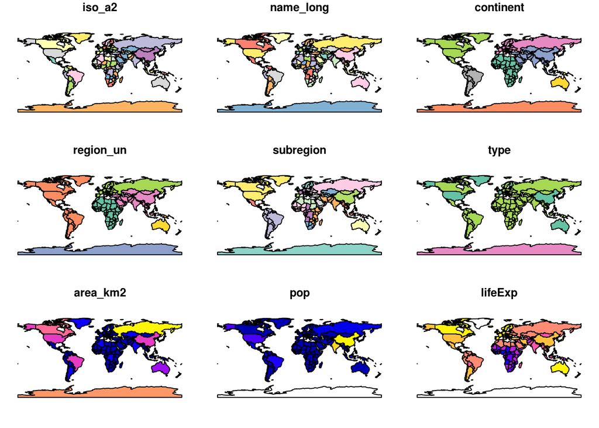

```r
plot(world)
```

# Referanslar

- [sf paketi](https://cran.r-project.org/web/packages/sf/)
- [sp paketi](https://cran.r-project.org/web/packages/sp/) (eski teknoloji)
- [Geocomputation with R](https://geocompr.robinlovelace.net/) (online kitap)
- r-spatial.org
- [Rspatial.org](http://www.rspatial.org/)
- Cran Task View : [Analysis of Spatial Data](https://cran.r-project.org/web/views/Spatial.html)

# Daha fazla bilgi için

**Servet Ahmet Çizmeli**, PranaGEO Ltd., Bodrum

**ahmet@pranageo.com**

# Bize yardım edin

**VisualR** kendine yeni bir isim arıyor… Platformumuzun isim annesi olmak ister misiniz?